Mini-projet : Analyse de la dépression chez les étudiants à l’aide des bibliothèques Pandas, NumPy et Matplotlib

Réalisé par : MOHAMED AIT MOUALI

Licence d'Excelence : IOTR

1-📝 Introduction:

## Objectif du projet

Ce projet a pour objectif de réaliser une analyse exploratoire du jeu de données intitulé **"Student Depression Dataset"**, qui regroupe des informations sur les étudiants et leur état de santé mentale.  
L’analyse porte principalement sur la recherche de tendances ou de facteurs pouvant être associés à la dépression chez les étudiants. Source data : https://www.kaggle.com/datasets/hopesb/student-depression-dataset/code

## Bibliothèques utilisées

Pour mener à bien cette étude, nous avons utilisé des bibliothèques Python puissantes et couramment employées en science des données :

- **Pandas** : pour la manipulation et l’analyse des données tabulaires
- **NumPy** : pour les opérations numériques et les calculs statistiques
- **Matplotlib** : pour la visualisation des données à travers des graphiques et des diagrammes

## Étapes de l’étude

L’étude s’est articulée autour de plusieurs étapes :

1. L’importation et l’exploration du jeu de données
2. Le nettoyage et la manipulation des données
3. L’analyse statistique descriptive
4. La représentation graphique des résultats

## Résultats

2- 🧩Démarche du mini-projet:

Dans ce mini-projet, nous avons suivi plusieurs étapes clés pour analyser les données du **Student Depression Dataset** :

### 1. Importation des données

Nous avons chargé le fichier CSV dans un DataFrame à l’aide de la bibliothèque **Pandas** afin de pouvoir manipuler facilement les données.

### 2. Exploration des données

Nous avons examiné les premières lignes du jeu de données, vérifié les types de variables, identifié les valeurs manquantes et consulté les statistiques descriptives de base.

### 4. Analyse statistique

Nous avons calculé des mesures telles que la moyenne, la médiane et l’écart-type, et nous avons regroupé les données par genre ou tranche d’âge afin de mieux comprendre la distribution des cas de dépression.

### 5. Visualisation des données

Enfin, nous avons utilisé la bibliothèque **Matplotlib** pour représenter graphiquement les résultats à l’aide d’histogrammes, de courbes et de boxplots, facilitant ainsi l’interprétation des tendances observées.

3- Code python:

✅ 1. Importation et chargement:

```python
import pandas as pd
import matplotlib.pyplot as plt
import numpy as np

# Charger le fichier CSV
df = pd.read_csv('Student Depression Dataset.csv')

# Afficher les 5 premières lignes
print(df.head())
```

```
   id  Gender   Age           City Profession  Academic Pressure  \
0   2    Male  33.0  Visakhapatnam    Student                5.0
1   8  Female  24.0      Bangalore    Student                2.0
2  26    Male  31.0       Srinagar    Student                3.0
3  30  Female  28.0       Varanasi    Student                3.0
4  32  Female  25.0         Jaipur    Student                4.0

   Work Pressure  CGPA  Study Satisfaction  Job Satisfaction  \
0            0.0  8.97                 2.0               0.0
1            0.0  5.90                 5.0               0.0
2            0.0  7.03                 5.0               0.0
3            0.0  5.59                 2.0               0.0
4            0.0  8.13                 3.0               0.0

      Sleep Duration Dietary Habits   Degree  \
```

[output cut: 19 more lines]

🔍 2. Exploration des données:

```python
# Infos générales sur le DataFrame
print(df.info())

# Statistiques de base
print(df.describe())

# Valeurs manquantes
print(df.isnull().sum())
```

```
<class 'pandas.core.frame.DataFrame'>
RangeIndex: 2318 entries, 0 to 2317
Data columns (total 18 columns):
 #   Column                                 Non-Null Count  Dtype
---  ------                                 --------------  -----
 0   id                                     2318 non-null   int64
 1   Gender                                 2318 non-null   object
 2   Age                                    2318 non-null   float64
 3   City                                   2318 non-null   object
 4   Profession                             2318 non-null   object
 5   Academic Pressure                      2318 non-null   float64
 6   Work Pressure                          2318 non-null   float64
 7   CGPA                                   2318 non-null   float64
 8   Study Satisfaction                     2318 non-null   float64
 9   Job Satisfaction                       2318 non-null   float64
 10  Sleep Duration                         2318 non-null   object
 11  Dietary Habits                         2318 non-null   object
 12  Degree                                 2318 non-null   object
 13  Have you ever had suicidal thoughts ?  2318 non-null   object
 14  Work/Study Hours                       2318 non-null   float64
 15  Financial Stress                       2318 non-null   float64
 16  Family History of Mental Illness       2318 non-null   object
 17  Depression                             2318 non-null   int64
dtypes: float64(8), int64(2), object(8)
memory usage: 326.1+ KB
None
                 id          Age  Academic Pressure  Work Pressure  \
count   2318.000000  2318.000000        2318.000000         2318.0
mean    5955.878775    25.754530           3.159620            0.0
std     3431.914932     4.884392           1.387244            0.0
min        2.000000    18.000000           1.000000            0.0
25%     3018.000000    21.000000           2.000000            0.0
50%     6008.500000    25.000000           3.000000            0.0
75%     8954.750000    30.000000           4.000000            0.0
max    11822.000000    42.000000           5.000000            0.0

              CGPA  Study Satisfaction  Job Satisfaction  Work/Study Hours  \
count  2318.000000         2318.000000       2318.000000       2318.000000
mean      7.686311            2.931838          0.001294          7.195427
std       1.461859            1.361222          0.062311          3.712736
```

[output cut: 19 more lines]

```
Profession                               0
Academic Pressure                        0
Work Pressure                            0
CGPA                                     0
Study Satisfaction                       0
Job Satisfaction                         0
Sleep Duration                           0
Dietary Habits                           0
Degree                                   0
Have you ever had suicidal thoughts ?    0
Work/Study Hours                         0
Financial Stress                         0
Family History of Mental Illness         0
Depression                               0
dtype: int64
```

🛠️ 3. Manipulation des données:

```python
# Sélection de colonnes spécifiques
print(df[['Age', 'Gender', 'Depression']])

# Filtrer : les étudiants dépressifs
depressed_students = df[df['Depression'] == 'Yes']
print(depressed_students)

# Créer une nouvelle colonne : "Age_Group"
df['Age_Group'] = pd.cut(df['Age'], bins=[15, 18, 22, 30], labels=['Teen', 'Young Adult', 'Adult'])
print(df[['Age', 'Age_Group']])

# Trier les données par Age décroissant
print(df.sort_values(by='Age', ascending=False))
```

```
       Age  Gender  Depression
0     33.0    Male           1
1     24.0  Female           0
2     31.0    Male           0
3     28.0  Female           1
4     25.0  Female           0
...    ...     ...         ...
2313  20.0    Male           0
2314  29.0    Male           0
2315  33.0  Female           0
2316  29.0  Female           0
2317  21.0    Male           1

[2318 rows x 3 columns]
Empty DataFrame
```

[output cut: 82 more lines]

📊 4. Analyse statistique:

```python
# Moyenne, médiane, écart-type
print("Moyenne d'âge :", df['Age'].mean())
print("Médiane d'âge :", df['Age'].median())
print("Écart-type d'âge :", df['Age'].std())

# Grouper par Genre et calculer la moyenne d'âge
print(df.groupby('Gender')['Age'].mean())

# Grouper par Age_Group et compter les cas de dépression
print(df.groupby('Age_Group')['Depression'].value_counts())
```

```
Moyenne d'âge : 25.75452976704055
Médiane d'âge : 25.0
Écart-type d'âge : 4.884391894260112
Gender
Female    25.524085
Male      25.941406
Name: Age, dtype: float64
Age_Group    Depression
Teen         1              92
             0              34
Young Adult  1             389
             0             189
Adult        1             685
             0             427
Name: count, dtype: int64
```

📈 5. Visualisation des données:

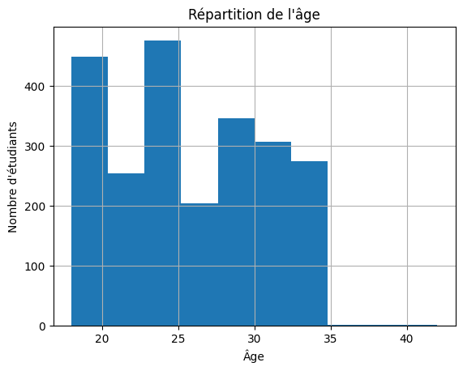

[figure not shown]

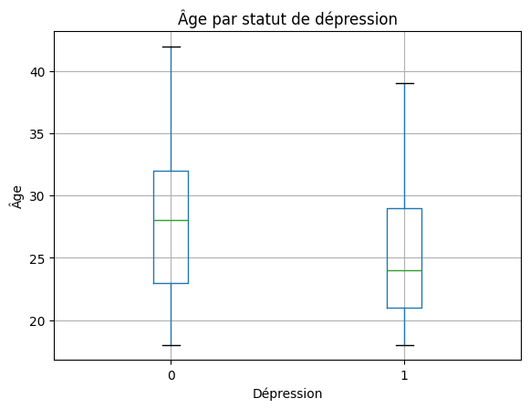

```python
# Histogramme de l'âge
df['Age'].hist(bins=10)
plt.title("Répartition de l'âge")
plt.xlabel("Âge")
plt.ylabel("Nombre d'étudiants")
plt.show()

# Courbe : nombre de cas de dépression par âge
df.groupby('Age')['Depression'].apply(lambda x: (x == 'Yes').sum()).plot()
plt.title("Cas de dépression par âge")
plt.xlabel("Âge")
plt.ylabel("Nombre de cas")
plt.show()

# Boxplot : âge selon la dépression
df.boxplot(column='Age', by='Depression')
plt.title("Âge par statut de dépression")
plt.suptitle("")
plt.xlabel("Dépression")
plt.ylabel("Âge")
plt.show()
```